# Ups and downs of log data: digital prescription example

11/26/2016

## In today's presentation

- X-road log data
- Digital prescription: looking for signs of diffusion

## What is *x-road*?

- Whenever service providers, regardless of their sector, require state confirmed (or owned) information, they can get it automatically through Estonia's e-government system
- However, e-government is not a single entity, but rather a network of different systems
- These different systems are connected by a specific information exchange layer called the **x-road**

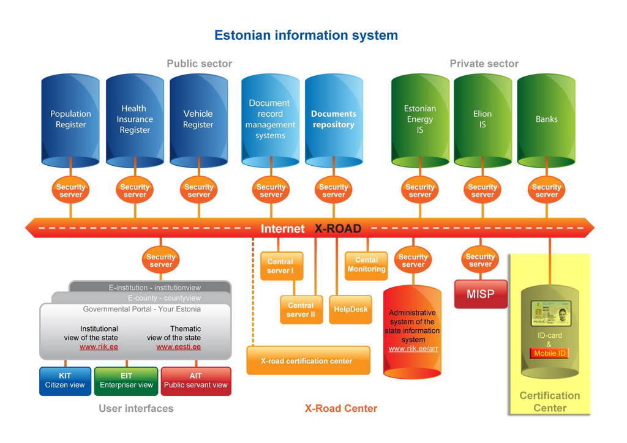

## What is *x-road*?

- Around 1500 services and 200 data repositories
- Widely used

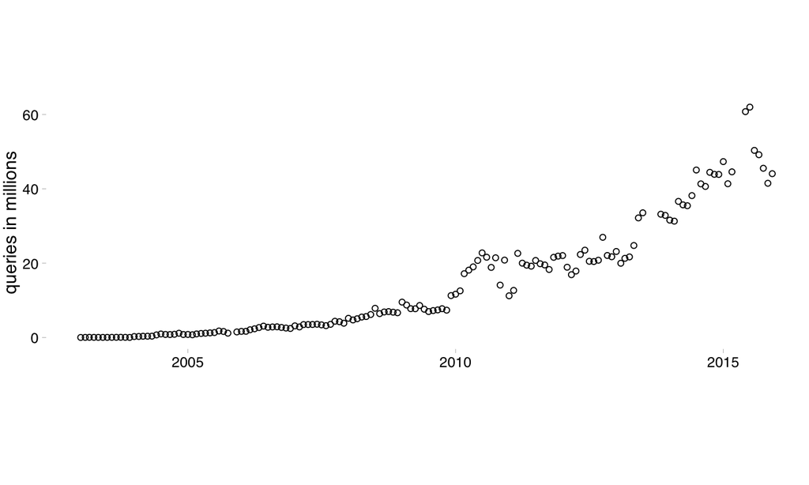

## What does x-road have offer?

- All x-road traffic is logged
  - For system maintenance and transparency reasons
- Only four variables are logged:
  - time
  - user
  - consumer
  - service
- Consequently, this log data can be used to analyze how different services are used
- Over 2 billion queries from 2003 to 2015

## Difficulties of using log data

- People who build and develop IT systems are not, in fact, social scientists!
  - While this is becoming less of a problem nowadays, it will still take years to reap the rewards
- Machine-to-machine communication is not easily distinguishable given the limited number of variables
- Missing data from system downtime

In short: there is a lot of noise and no easy way to filter it

## Digital prescription

## Digital prescription

- Service description
- General uptake patterns
- First and n<sup>th</sup> time users

## Service description

- Digital prescription service was developed in conjunction with a few other health related e-services (digital health records, appointment registration etc)
- Is compulsory for pharmacies, but patients can still opt for paper-based prescriptions if they wish to do so
- Went online in 2010

## Service description

- As with many other services, no one "digital prescription" service exists, rather a number of smaller services connected to the same object (prescription):
  - Writing prescriptions (for doctors)
  - Checking your list of prescriptions or individual prescriptions
  - Checking your patients' prescriptions (for doctors)
  - Business related services for pharmacies (are prescriptions still valid, who is eligible for discounts etc)

## General uptake patterns

- To measure that, we have to:
  - Count the number of unique prescriptions
  - Differentiate between paper-based and digital prescriptions (or know their sum)
- Log data does not provide information about the object of the query
- Therefore, if we want to measure unique prescriptions, we have to find a proxy indicator for it

## General uptake patterns

- Two services stand out:
  - Assigning purchase information - indicates that a purchase was made
  - Digitization service - indicates that a purchase was made using a paper-based prescription

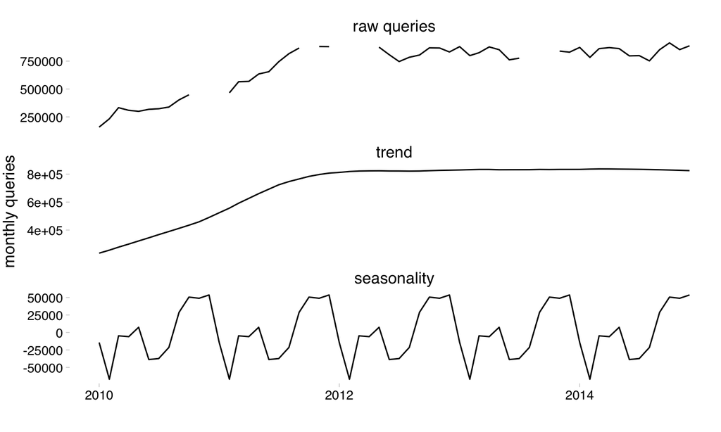

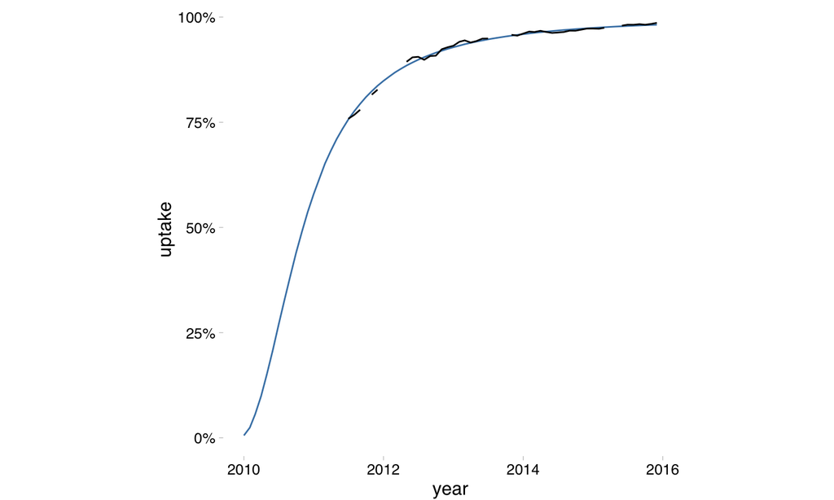

\({Y} = \frac{1}{1 + 0.86{e}^{-2.14{\ln}(x)}}\)

## General uptake patterns

- While there are more efficient methods for modeling uptake, this demonstrates that we do get fairly accurate results with log data analysis

## First and n<sup>th</sup> time users

- In order to go further we should look how this service has diffused in different user groups and what kind of people use it more often
  - In other words: diffusion among specific user groups (age, gender, number of times used)
- Previous services do not contain information on patients, which is why have to rely on additional *sub-services*

## First and n<sup>th</sup> time users

- One of these services returns a list of prescriptions to the user (note: not patient!)
  - Gets called when users visit health related e-services or explicitly requests it from e-government's webpage
  - Around 20 000 queries every month
  - Used more by females and younger people

## First and n<sup>th</sup> time users

- To explore diffusion in different user groups, we would have create a *usage counter* for every unique user
- For illustrative purposes we can continue with only the age variable

## First and n<sup>th</sup> time users

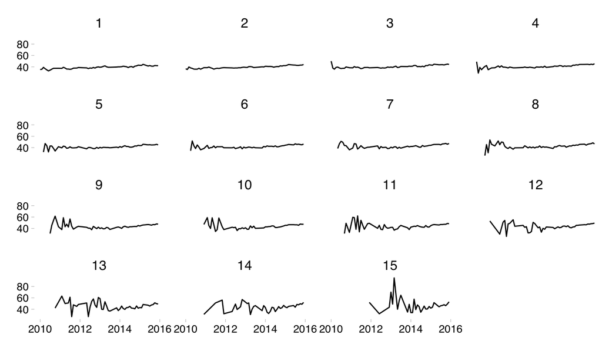

## First and n<sup>th</sup> time users

- Since the true diffusion pattern seems linear, we may apply a linear model to clean our data from machine-generated noise

## First and n<sup>th</sup> time users

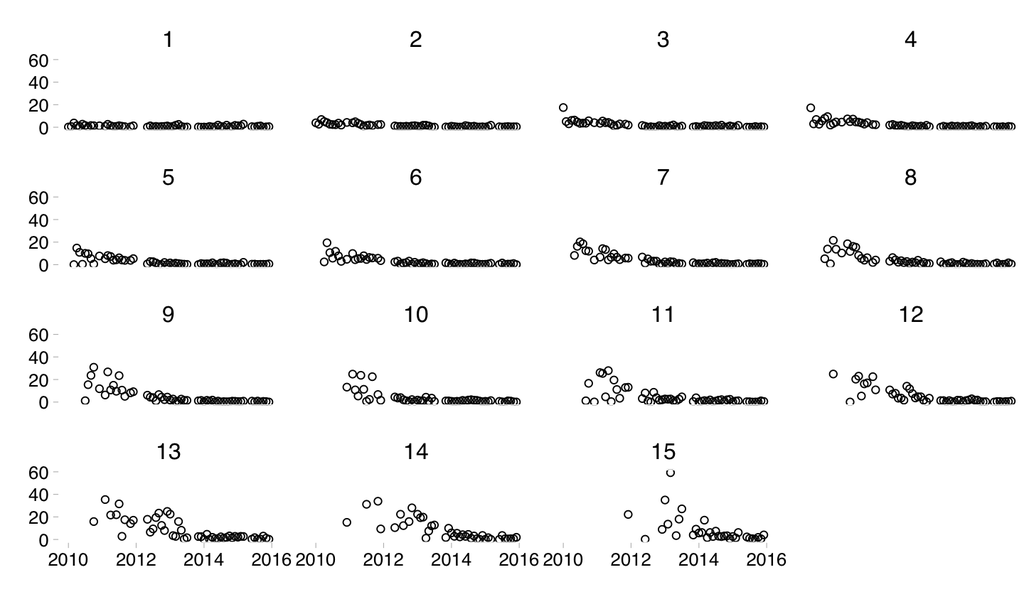

## First and n<sup>th</sup> time users

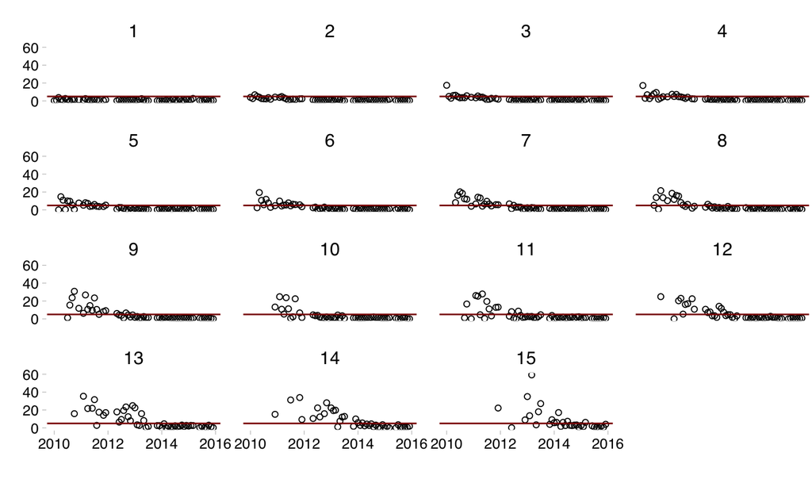

## First and n<sup>th</sup> time users

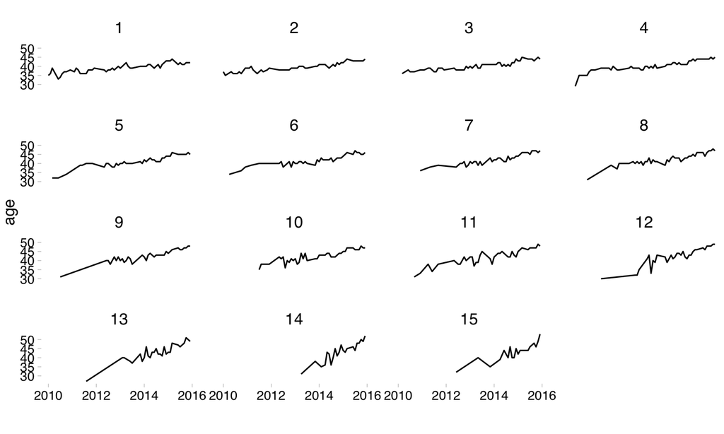

## First and n<sup>th</sup> time users

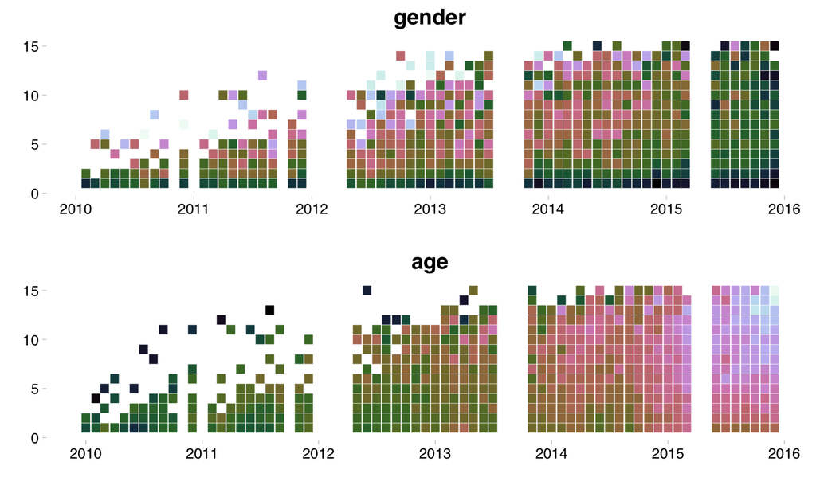

## First time users: total

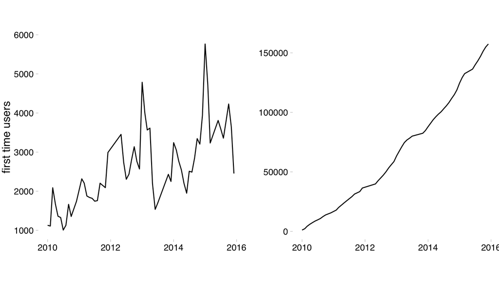

## First time users: by age

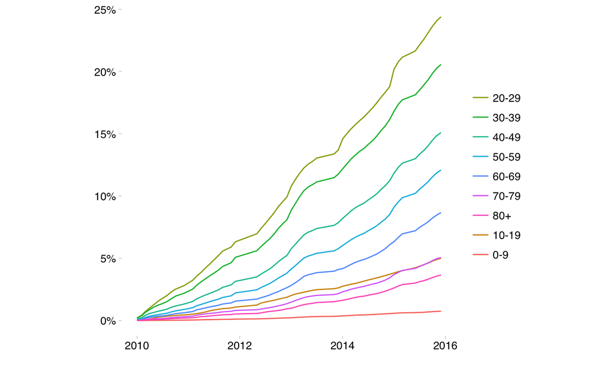

Thank you!  
marten.veskimae@ut.ee